# Introduction to MATLAB Programming

EE1021 Programming for Engineers - Lecture 12

Basri Erdogan

## Introduction to MATLAB

Focus today: quick wins with the command window, tidy variables, fast matrix work.

Python → MATLAB quick wins:

- 1-based indexing, `()` for access, `end` closes blocks.
- `;` suppresses output; `ans` holds unnamed results.
- `.*` / `./` for element-wise; `*` for matrix mult.
- Save/load `.mat`; functions live in their own `.m` file.

## What is MATLAB?

- Matrix-first numerical environment, ideal for quick prototyping.
- “Programmable calculator” with built-in visualization.
- Best when you think in vectors and matrices.
- Coming from Python: similar numeric goals, but 1-based indexing, column-major order, and `end` to close blocks.

## Why use MATLAB?

- Polished plotting/UI out of the box (no Matplotlib boilerplate).
- Toolboxes for control, signal, stats, optimization without extra installs.
- Tight integration with hardware/Simulink and quick GUIs for lab rigs.
- IDE/debugger tuned for matrices; live scripts with sliders/inputs.
- Great for sharing with non-programmers (students, lab mates) who just run scripts.

## Command Window: quick math

- Command window = scratchpad; type expression, press return, see result.
- Spaces do not matter; use it like a calculator.
- Try:

```matlab
2 + 3*5
(10 + 4) / 3
sin(pi/4)
```

## Using Variables

- Assign and reuse with `=`; unnamed output goes into `ans`.
- End a line with `;` to suppress printed output (Python only prints when you call `print`).
- Workspace shows live variables; clear with `clear` (all) or `clear name`.

```matlab
r = 5;
area = pi * r^2;   % saved, not printed
area
clear r
```

## Naming rules & built-ins

- Case-sensitive, start with a letter, use letters/numbers/`_` only.
- Avoid MATLAB keywords; MATLAB will warn you if you clash.
- Handy built-ins: `pi`, `i`/`j`, `inf`, `nan`, `eps`.
- Python contrast: no implicit imports—these are always in scope.

```matlab
radius_cm = 5;
area = pi * radius_cm^2;
machine_tol = eps;
ok_name = isvarname('user_id');
bad_name = isvarname('3cars');
```

## Matrices and Arrays

- Everything is an array; build them with brackets and colons.
- Rows separated by semicolons; ranges use `start:stop` or `start:step:stop`.

```matlab
v = [1 2 3 4];        % row vector
M = [1 2; 3 4; 5 6];  % 3x2 matrix
t = 0:0.5:2.5;        % 0 0.5 1.0 1.5 2.0 2.5
```

## Matrices and Arrays (Operations)

- `.*` and `./` for element-wise; plain `*` and `/` for matrix math.
- Indexing: `A(n)` or `A(row,col)`; rows first, then columns.
- Slices: `A(row,:)`, `A(:,col)`, `A(:)` to flatten.
- Python contrast: indices start at 1, use `()` not `[]`, and element-wise uses `.*` (NumPy’s default is element-wise).

```matlab
A = [1 2; 3 4];
B = [10 20; 30 40];
elementwise = A .* B;   % [10 40; 90 160]
matmul = A * B;         % matrix multiply
row2 = A(2, :);         % row slice
lastcol = B(:, end);    % column slice
flat = A(:);            % linearized
```

## Array Subscripting / Indexing

Consider Matrix A:

```matlab
A =
1   6   11  16  21
2   7   12  17  22
3   8   13  18  23
4   9   14  19  24
5   10  15  20  25
```

**Examples:**

- `A(3,1)` → 3
- `A(3)` → 3 (Linear indexing)
- `A(1:5,5)` → Column 5
- `A(:,5)` → Column 5
- `A(21:25)` → Elements 21 to 25
- `A(4:5,2:3)` → Sub-matrix
- `A([9 14;10 15])` → Indexing with matrix
- `A(:,end)` → Last column

## The Variable Editor

- Double-click a variable in the workspace to open the editor.
- Edit values directly like a spreadsheet; great for quick fixes.
- `who` lists current variables from the command line.

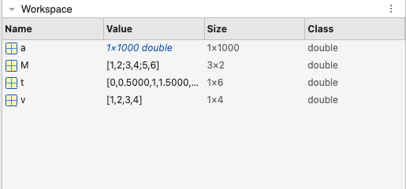

## The Command History

- MATLAB stores recent commands; double-click to rerun (watch for changed variables).
- Use the up-arrow to search through history; start typing to filter.
- `clc` clears the command window; history stays.

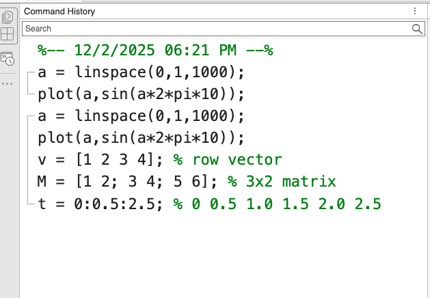

## Functions

- Learn the built-ins first: `mean`, `std`, `plot`, `sum`, `linspace`, etc.
- Standard pattern:

```matlab
[out1, out2] = function_name(in1, in2);
```

- If you skip the output, it goes into `ans`.

```matlab
[m, s] = mean_and_std([1 2 3 4 5]);
```

## Common Functions

- `mean`: compute mean
- `std`: compute standard deviation
- `min` / `max`: min/max values
- `rand` / `randn`: random numbers
- `size`: size of a matrix
- `randperm`: random permutation
- `sqrt`: square root
- `find`: find indices satisfying condition

```matlab
vals = randn(1,5);
mu = mean(vals);       % black keyword, magenta vars
sigma = std(vals);
mn = min(vals);
mx = max(vals);
perm = randperm(5,3);
pos_idx = find(vals > 0);
shape = size(vals);
```

*Python parallels:* `mean/std/min/max` ~ `numpy.mean/std/min/max`; `rand`/`randn` ~ `np.random.rand/randn`; `find(cond)` ~ `np.where(cond)`; `size(A)` ~ `A.shape`.

## Data Handling

- Save workspace: `save mysession` (creates `mysession.mat` in current folder).
- Load later with `load mysession`; watch for name collisions.
- Adjust the search path if files live outside the current folder.
- Python contrast: `save/load` writes `.mat` (like `pickle`/`np.save`); loading can overwrite variables in the base workspace.

```matlab
save my_data.mat;
clear;
load my_data.mat;
```

## Getting Help

- `help function` for quick docs; `doc function` for full examples.
- `demo` shows built-in walkthroughs.
- MathWorks docs are excellent; community answers are everywhere.
- If stuck: search the function name + “MATLAB example.”
- Python parallel: `doc func` ~ `help(func)`; use `which func` to see the file being called (like `inspect.getfile`).

```matlab
doc plot
help sin
```

# Basics of Programming

## Why program in MATLAB?

- Ubiquitous in engineering labs and courses; matches what industry expects.
- Hardware/Simulink integration makes control/signal prototypes fast.
- Live scripts mix narrative, code, and plots for easy sharing.
- Toolboxes remove dependency wrangling (no pip/conda env drift).
- Friendly for non-programmers to run and tweak scripts without setup.

## MATLAB Data Structures: Strings

- MATLAB deals with many different types of variable.
- So far we have only considered single numbers, arrays and matrices.
- MATLAB can also operate on **strings**, which are just text variables.
- Strings are entered using single quotation marks `' '` (double quotes give string scalars; both differ from Python’s list of chars).
- Strings can be treated much the same as numeric variables.
- They can be concatenated, but follow standard rules.
- The functions `int2str` and `num2str` convert numbers to strings, for display reasons.
- The function `disp` displays a string in the MATLAB command window.

## MATLAB Data Structures: Strings (Example)

```matlab
s1 = 'Hello';
s2 = 'World';
msg = [s1 ' ' s2]; % Concatenation
disp(msg);
num_str = num2str(42);
```

## MATLAB Data Structures: Cells and Structures

## Cell Arrays

- Hold mixed shapes/types in one container using `{ }`.
- Access elements with `{ }`, then index inside with `()`.
- Great for variable-length strings or mixed objects.
- Think “cell array ≈ Python list (mixed types allowed).”

```matlab
words = {'foo', 'longer phrase', 'bar'};
words{2}          % returns 'longer phrase'
sizes = [numel(words{1}), numel(words{2})];
```

## Structures

- Group related data by field name: `struct.field`.
- Useful for participant records: names + data together.
- Fields can hold any type, even nested structs.
- Think “struct ≈ Python dict with dot access.”

```matlab
p.name = 'Ali';
p.score = [88 92 90];
p.meta.id = 42;
```

## Creating a script

- New script: “New script”, `Ctrl+N`, or File -> New -> Script.
- Scripts are `.m` files that run top-to-bottom.
- Use current folder or add paths so MATLAB can find the file.

[figure not shown]

## Running a script

- Save then run with **Run** (F5); highlighted region runs with F9.
- Scripts share the base workspace (they see current variables).
- Keep the Current Folder set to where the script lives.

[figure not shown]

## Annotating Code

- Comment with `%`; block comments: `%{ ... %}`.
- Use `%%` to split code into runnable cells (Ctrl+Enter).
- Long lines: end with `...` to continue.

```matlab
%% load data
x = 1:5;  % inline comment
```

## More Advanced Programming

- Conditionals choose branches; loops repeat work.
- Always update loop conditions; `Ctrl+C` stops a runaway loop.
- Start simple: one `if`, one `for`, then expand.

```matlab
% MATLAB closes blocks with end (Python uses indent/colon)
for i = 1:3
    if i == 2
        disp("middle")
    end
end
```

## Review of MATLAB Operators

**Relational**

| op | meaning |
| --- | --- |
| `==` | equal to |
| `<` | less than |
| `>` | greater than |
| `<=` | less than or equal to |
| `>=` | greater than or equal to |
| `~=` | not equal to |

**Logical**

| op | meaning |
| --- | --- |
| `&&` | logical and |
| `\|\|` | logical or |
| `&` | element-wise and |
| `\|` | element-wise or |

## ‘If’ Statements

- Use `if` to execute code **only if** a condition is true.
- Must end with `end`.
- Use `else` or `elseif` for alternatives.
- **Note:** `elseif` is different from `else if` (nested).

```matlab
temp = 32;
if temp > 30
    label = "hot";
elseif temp > 15
    label = "mild";
else
    label = "cold";
end
```

## ‘Switch/Case’ Statements

- Evaluates a **single variable** against multiple options.
- Cleaner than many nested `elseif`s.
- Often used for string comparisons.
- Must end with `end`.

```matlab
day = "Mon";
switch day
    case {"Sat","Sun"}
        kind = "weekend";
    case {"Mon","Tue","Wed","Thu","Fri"}
        kind = "weekday";
    otherwise
        kind = "unknown";
end
```

## ‘For’ Loops

- Repeat an operation a specific number of times.
- Loops through values in a vector (e.g., `1:n`).
- Can be nested.

```matlab
vals = [2 4 6 8];
sum_sq = 0;
doubles = zeros(size(vals));  % preallocate outputs
for i = 1:numel(vals)
    doubles(i) = vals(i)*2;
    sum_sq = sum_sq + vals(i)^2;
end
avg_sq = sum_sq / numel(vals);
```

## ‘While’ Loops

- Repeat **until** a condition is met.
- **Critical:** Update the condition variable inside the loop!
- **Warning:** Avoid infinite loops. Use `ctrl+c` to break.

```matlab
n = 3;
total = 0;
while n > 0
    total = total + n;
    disp(n)
    n = n - 1;
end
fprintf("Total = %d\n", total);
```

## Writing Functions

```matlab
% File: summarize_readings.m
function [avg, spread] = summarize_readings(readings)
    if nargin == 0
        error("Need readings input");
    end
    avg = mean(readings);
    spread = std(readings);
end
```

- Unlike scripts, functions use their own ‘private’ workspace.
- Any required input must be passed directly to the function.
- Only assigned output will be delivered to the (base) workspace.
- Help information can be entered in comments at the top of the function script.
- Save the file with the same name as the function (e.g., `summarize_readings.m`).

## Debugging

- Red underlines = errors; orange = warnings; hover to see hints.
- Use `disp`/`fprintf` to print variables while you iterate.
- MATLAB suggestions help but are not always correct.

## Debugging (Breakpoints)

- Click the gutter to set a breakpoint (red dot).
- Code runs to that line; then you can step line-by-line.
- Inspect variables in the workspace while paused; click again to clear.

## Debugging (Visual)

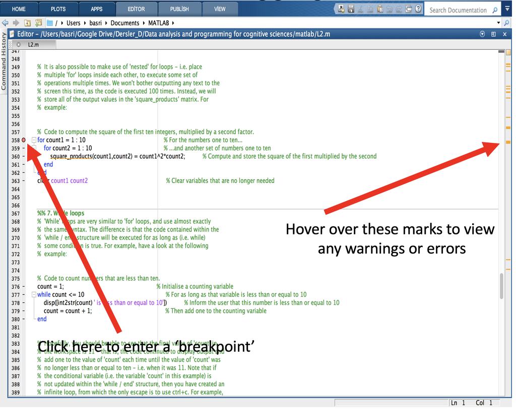